# Reproducible Research Project 2

Sangwon Han

2018년 12월 27일

# Synopsis

The basic goal of this project is to explore the NOAA Storm Database and answer some basic questions about severe weather events. The data analysis is for addressing the following questions:

1. Across the United States, which types of events are most harmful with respect to population health?
2. Across the United States, which types of events have the greatest economic consequences?

# Read and preprocess data

## Set working directory and read the data

```r
getwd()
url <- "https://d396qusza40orc.cloudfront.net/repdata%2Fdata%2FStormData.csv.bz2"
download.file(url, "StormData.csv.bz2")
df <- read.csv("StormData.csv.bz2", header=TRUE, sep=",")
```

## Explore and clean data

```r
str(df)
```

```
## 'data.frame':    692288 obs. of  37 variables:
##  $ STATE__   : Factor w/ 82073 levels ",563736.00\n72.00,3/28/2004 0:00:00,04:17:00 PM,AST,4.00,PRZ004,PR,FLOOD,0.00,,,3/28/2004 0:00:00,04:17:00 PM,0"| __truncated__,..: 56643 56643 56643 56643 56643 56643 56643 56643 56643 56643 ...
##  $ BGN_DATE  : Factor w/ 92372 levels " at Barrio Ca\xf1aboncito in the municipality of Caguas",..: 83652 83652 81717 87755 80130 80130 80159 78656 81511 81511 ...
##  $ BGN_TIME  : Factor w/ 58103 levels " Central and South Central,,4506.00,9522.00,4506.00,9522.00,A tornado was reported by a storm chaser on the gro"| __truncated__,..: 55197 55212 57408 56612 57347 57672 55167 56612 57672 57672 ...
##  $ TIME_ZONE : Factor w/ 45970 levels ""," "," over 10 bridges were underwater. Many roadways sustained damage from the flood waters. Rainfall totals reached"| __truncated__,..: 45948 45948 45948 45948 45948 45948 45948 45948 45948 45948 ...
##  $ COUNTY    : Factor w/ 41476 levels ""," "," -11 and -14.  Finally",..: 41465 41004 41284 41449 41136 41397 41451 40812 40814 41284 ...
##  $ COUNTYNAME: Factor w/ 53650 levels " has been releasing on a fairly regular basis for the past 40 years. During these outburst floods (known as j\xf6kulhlaups)",..: 44917 38133 40142 43230 39921 43010 38229 50638 50844 40142 ...
##  $ STATE     : Factor w/ 34431 levels " along County Road 3. It slightly damaged a nearby farmhouse and a cornfield along 790th Avenue about \xbd mile"| __truncated__,..: 34357 34357 34357 34357 34357 34357 34357 34357 34357 34357 ...
##  $ EVTYPE    : Factor w/ 32820 levels " over 10 bridges were underwater. Many roadways sustained damage from the flood waters. Rainfall totals reached"| __truncated__,..: 32669 32669 32669 32669 32669 32669 32669 32669 32669 32669 ...
##  $ BGN_RANGE : Factor w/ 30317 levels " Pe\xf1uelas",..: 29607 29607 29607 29607 29607 29607 29607 29607 29607 29607 ...
##  $ BGN_AZI   : Factor w/ 28654 levels ""," -18 degrees in Plattsburgh (Clinton) and -16 degrees in Ellenburg Depot (Clinton).,671604.00\n36.00,1/25/2007 "| __truncated__,..: 1 1 1 1 1 1 1 1 1 1 ...
##  $ BGN_LOCATI: Factor w/ 66973 levels "","- 1 N Albion",..: 1 1 1 1 1 1 1 1 1 1 ...
##  $ END_DATE  : Factor w/ 30264 levels ""," -10 to -30 C. layer",..: 1 1 1 1 1 1 1 1 1 1 ...
##  $ END_TIME  : Factor w/ 28232 levels ""," "," -10 to -30 C. layer",..: 1 1 1 1 1 1 1 1 1 1 ...
##  $ COUNTY_END: Factor w/ 24350 levels ""," "," -10 to -30 C. layer of the atmoshpere",..: 23922 23922 23922 23922 23922 23922 23922 23922 23922 23922 ...
```

[output cut: 23 more lines]

```r
head(df)
```

```
##   STATE__           BGN_DATE BGN_TIME TIME_ZONE COUNTY COUNTYNAME STATE
## 1    1.00  4/18/1950 0:00:00     0130       CST  97.00     MOBILE    AL
## 2    1.00  4/18/1950 0:00:00     0145       CST   3.00    BALDWIN    AL
## 3    1.00  2/20/1951 0:00:00     1600       CST  57.00    FAYETTE    AL
## 4    1.00   6/8/1951 0:00:00     0900       CST  89.00    MADISON    AL
## 5    1.00 11/15/1951 0:00:00     1500       CST  43.00    CULLMAN    AL
## 6    1.00 11/15/1951 0:00:00     2000       CST  77.00 LAUDERDALE    AL
##    EVTYPE BGN_RANGE BGN_AZI BGN_LOCATI END_DATE END_TIME COUNTY_END
## 1 TORNADO      0.00                                            0.00
## 2 TORNADO      0.00                                            0.00
## 3 TORNADO      0.00                                            0.00
## 4 TORNADO      0.00                                            0.00
## 5 TORNADO      0.00                                            0.00
## 6 TORNADO      0.00                                            0.00
##   COUNTYENDN END_RANGE END_AZI END_LOCATI LENGTH  WIDTH F  MAG FATALITIES
```

[output cut: 20 more lines]

```r
tail(df)
```

[output not shown]

[output cut: 65 more lines]

There must be an error in the dataset, so find the location of the source of error in “STATE” colunm (having 2 character, normally)

```r
sum(nchar(as.character(df$STATE)[1:570290])==2)
```

```
## [1] 547364
```

Something wrong in 547364th row

```r
View(df[547363:547365,])
```

The problem exist in [END_RANGE] in 547364th row.

```r
df$END_RANGE[547364]
```

```
## [1]  due to mainly to many roads being washed out.,547303.00\n36.00,5/24/2004 0:00:00,10:30:00 PM,EST,38.00,NYZ038,NY,FLOOD,0.00,,,5/26/2004 0:00:00,04:04:00 PM,0.00,,0.00,,,0.00,0.00,,0.00,0.00,0.00,0.00,,0.00,,ALY,NEW YORK
## 23406 Levels:  ...
```

Load data using [readLines] function, again. (The quote mark is \“)

```r
df1 <- readLines(con="StormData.csv.bz2")
df1[1:2]
```

```
## [1] "\"STATE__\",\"BGN_DATE\",\"BGN_TIME\",\"TIME_ZONE\",\"COUNTY\",\"COUNTYNAME\",\"STATE\",\"EVTYPE\",\"BGN_RANGE\",\"BGN_AZI\",\"BGN_LOCATI\",\"END_DATE\",\"END_TIME\",\"COUNTY_END\",\"COUNTYENDN\",\"END_RANGE\",\"END_AZI\",\"END_LOCATI\",\"LENGTH\",\"WIDTH\",\"F\",\"MAG\",\"FATALITIES\",\"INJ…
## [2] "1.00,4/18/1950 0:00:00,\"0130\",\"CST\",97.00,\"MOBILE\",\"AL\",\"TORNADO\",0.00,,,,,0.00,,0.00,,,14.00,100.00,\"3\",0.00,0.00,15.00,25.00,\"K\",0.00,,,,,3040.00,8812.00,3051.00,8806.00,,1.00"
```

Find the line having problem

```r
grep("547303.00", df1)
```

```
## [1] 884718
```

```r
df1[884718]
```

```
## [1] "\tA stationary front settled across eastern New York and adjacent western New England on the 23rd of May.  At the same time, a strong jetstream extended from the Great Lakes region, eastward to New England. A series of Mesoscale Convective  Systems (MCS) propagated along this front,  produci…
```

The problem is [\“] in the sentences. Therefore, let’s remove it

```r
tmp1 = gsub("\"\" ","", df1)
writeLines(tmp1, "StormData1.txt")
df_edited <- read.table("StormData1.txt", sep=",", quote = "\"", header = T)
dim(df_edited)
```

```
## [1] 902297     37
```

# Process data

## Extract variables for health and economic data

```r
health <- c("EVTYPE", "FATALITIES", "INJURIES")
healthData <- df_edited[,health]
economic <- c("EVTYPE", "CROPDMG", "CROPDMGEXP", "PROPDMG", "PROPDMGEXP")
economicData <- df_edited[,economic]
```

## Process health data

```r
str(healthData)
```

```
## 'data.frame':    902297 obs. of  3 variables:
##  $ EVTYPE    : Factor w/ 985 levels "   HIGH SURF ADVISORY",..: 834 834 834 834 834 834 834 834 834 834 ...
##  $ FATALITIES: num  0 0 0 0 0 0 0 0 1 0 ...
##  $ INJURIES  : num  15 0 2 2 2 6 1 0 14 0 ...
```

```r
health_event <- aggregate(cbind(FATALITIES, INJURIES) ~ EVTYPE, data=healthData, FUN=sum, na.rm = TRUE)
health_event$TOTAL <- health_event$FATALITIES + health_event$INJURIES
```

arrange data in descending order, extract top 10 events, and use [melt] function for grouped bar chart

```r
library(dplyr)
health_event <- arrange(health_event, desc(TOTAL))
top10_health <- health_event[1:10, ]
top10_health
```

```
##               EVTYPE FATALITIES INJURIES TOTAL
## 1            TORNADO       5633    91346 96979
## 2     EXCESSIVE HEAT       1903     6525  8428
## 3          TSTM WIND        504     6957  7461
## 4              FLOOD        470     6789  7259
## 5          LIGHTNING        816     5230  6046
## 6               HEAT        937     2100  3037
## 7        FLASH FLOOD        978     1777  2755
## 8          ICE STORM         89     1975  2064
## 9  THUNDERSTORM WIND        133     1488  1621
## 10      WINTER STORM        206     1321  1527
```

```r
library(reshape2)
top10_health_melt <- melt(top10_health, id.vars = "EVTYPE")
```

# Draw bar chart for health impact

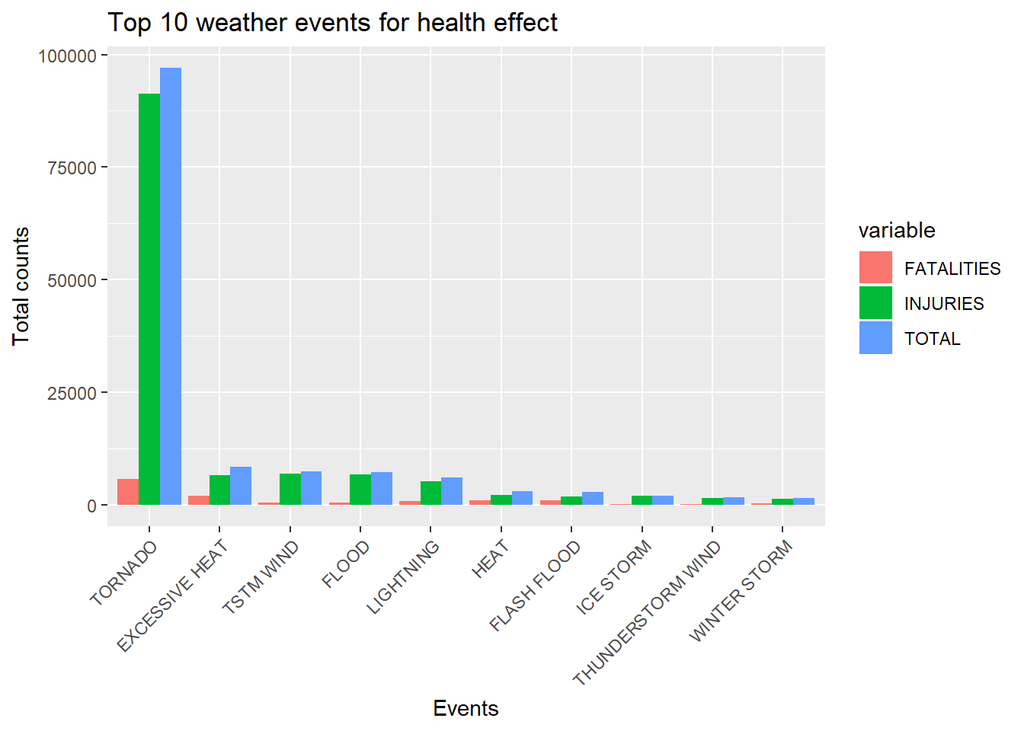

```r
library(ggplot2)
fig_health <- ggplot(top10_health_melt, aes(x = reorder(EVTYPE, -value), y = value)) +
                geom_bar(stat = "identity", aes(fill = variable), position = "dodge") +
                xlab("Events") + theme(axis.text.x = element_text(angle = 45, hjust = 1)) +
                ylab("Total counts") +
                ggtitle("Top 10 weather events for health effect")
fig_health
```

[TORNADO] is the most harmful with respect to population health!!

## Process economic data

```r
table(economicData$CROPDMGEXP)
```

```
##
##             ?      0      2      B      k      K      m      M
## 618413      7     19      1      9     21 281832      1   1994
```

```r
table(economicData$PROPDMGEXP)
```

```
##
##             -      ?      +      0      1      2      3      4      5
## 465934      1      8      5    216     25     13      4      4     28
##      6      7      8      B      h      H      K      m      M
##      4      5      1     40      1      6 424665      7  11330
```

```r
str(economicData$CROPDMGEXP)
```

```
##  Factor w/ 9 levels "","?","0","2",..: 1 1 1 1 1 1 1 1 1 1 ...
```

change character into numeric values in [CROPDMGEXP] and [PROPDMGEXP] columns. At first, I made a function

```r
trans <- function(x){
        if(x=="?"|x=="-"|x=="+"|x==""){
                x <- 1
        }else if(x=="h"|x=="H"){
                x <- 10^2
        }else if(x=="k"|x=="K"){
                x <- 10^3
        }else if(x=="m"|x=="M"){
                x <- 10^6
        }else if(x=="b"|x=="B"){
                x <- 10^9
        }else{
                x <- 10^(as.numeric(x))
        }
}
```

Transform the values

```r
economicData$CROPDMGEXP_trans <- sapply(as.character(economicData$CROPDMGEXP), trans)
table(economicData$CROPDMGEXP_trans)
```

```
##
##      1    100   1000  1e+06  1e+09
## 618439      1 281853   1995      9
```

```r
economicData$PROPDMGEXP_trans <- sapply(as.character(economicData$PROPDMGEXP), trans)
table(economicData$PROPDMGEXP_trans)
```

```
##
##      1     10    100   1000  10000  1e+05  1e+06  1e+07  1e+08  1e+09
## 466164     25     20 424669      4     28  11341      5      1     40
```

calculate the sum of the values

```r
economicData$CROP_total <- economicData$CROPDMGEXP_trans * economicData$CROPDMG
economicData$PROP_total <- economicData$PROPDMGEXP_trans * economicData$PROPDMG
```

I calculate the sum of each value according to the type of events. Then, arrange data in descending order, extract top 10 events, and use [melt] function for grouped bar chart

```r
economic_event <- aggregate(cbind(CROP_total, PROP_total) ~ EVTYPE, data = economicData, FUN=sum, na.rm = TRUE)
economic_event$SUM <- economic_event$CROP_total + economic_event$PROP_total
economic_event <- arrange(economic_event, desc(SUM))
top10_economic <- economic_event[1:10, ]
top10_economic
```

```
##               EVTYPE  CROP_total   PROP_total          SUM
## 1              FLOOD  5661968450 144657709807 150319678257
## 2  HURRICANE/TYPHOON  2607872800  69305840000  71913712800
## 3            TORNADO   414953270  56947380677  57362333947
## 4        STORM SURGE        5000  43323536000  43323541000
## 5               HAIL  3025954473  15735267513  18761221986
## 6        FLASH FLOOD  1421317100  16822673979  18243991079
## 7            DROUGHT 13972566000   1046106000  15018672000
## 8          HURRICANE  2741910000  11868319010  14610229010
## 9        RIVER FLOOD  5029459000   5118945500  10148404500
## 10         ICE STORM  5022113500   3944927860   8967041360
```

```r
colnames(top10_economic) <- c("EVTYPE", "CROP", "PROPERTY", "TOTAL")
top10_economic_melt <- melt(top10_economic, id.vars = "EVTYPE")
```

# Draw bar chart for Economic impact

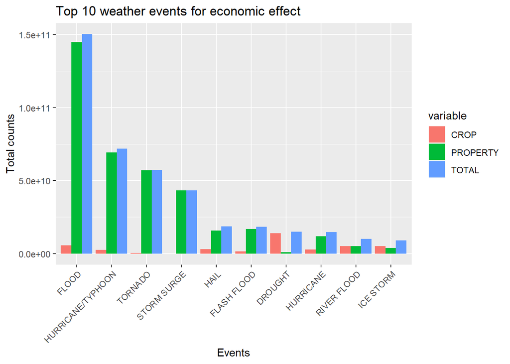

```r
fig_economic <- ggplot(top10_economic_melt, aes(x = reorder(EVTYPE, -value), y = value)) +
        geom_bar(stat = "identity", aes(fill = variable), position = "dodge") +
        xlab("Events") + theme(axis.text.x = element_text(angle = 45, hjust = 1)) +
        ylab("Total counts") +
        ggtitle("Top 10 weather events for economic effect")
fig_economic
```

Therefore, [FLOOD] is the event having the greatest economic consequence!!